# Project 4: Movie Recommendation System

Deeraj(NetID: svk5), Chiranjeevi(NetID: konduru4), Sandeep(NetID: sy40)

2022-12-12

# Team members and contributions

We analyzed the problem statement and each of us worked individually at the beginning and tried our own approaches. We reviewed each others contribution and finalized the code together and constructed a report.

● Chiranjeevi : System 1 - Approach 1 and 2, Report Writing.

● Deeraj : System 2 - IBCF and UBCF , Code Merge and final submission.

● Sandeep : Exploratory Data Analysis, Server and UI.

## Goal

The goal of this project is to build an end-to-end web application to implement, configure and evaluate recommender systems using different approaches. To achieve this, the assignment calls for using a user-item ratings dataset (from MovieLens in this case) and implement two recommendation algorithms:

```
    - Recommendations by Movie Genres

    - Recommendations by Collaborative Filtering Algorithm
```

The evaluation should compare these approaches based on their accuracy using normalization techniques, similarity methods, neighborhood sizes, etc.

## EDA

```r
library(dplyr)
```

```r
library(ggplot2)
library(recommenderlab)
library(DT)
library(data.table)
library(reshape2)
```

### Reading Data

```r
 myurl = "https://liangfgithub.github.io/MovieData/"
```

**Ratings Data** All ratings are contained in the file “ratings.dat” and are in the following format:

UserID::MovieID::Rating::Timestamp

- UserIDs range between 1 and 6040
- MovieID ranges from 1 to 3952, but not all of them are included in movies. Further, 177 movies are in movies but not rated in ratings.
- Ratings are made on a 5-star scale
- Timestamp is represented in seconds

```r
ratings = read.csv(paste0(myurl, 'ratings.dat?raw=true'),
                   sep = ':',
                   colClasses = c('integer', 'NULL'),
                   header = FALSE)
colnames(ratings) = c('UserID', 'MovieID', 'Rating', 'Timestamp')
head(ratings,5)
```

|  | UserID | MovieID | Rating | Timestamp |
| --- | --- | --- | --- | --- |
| 1 | 1 | 1193 | 5 | 978300760 |
| 2 | 1 | 661 | 3 | 978302109 |
| 3 | 1 | 914 | 3 | 978301968 |
| 4 | 1 | 3408 | 4 | 978300275 |
| 5 | 1 | 2355 | 5 | 978824291 |

**Movies Data** Movie information is in the file “movies.dat” and is in the following format:

MovieID::Title::Genres

- Movie Titles are similar to the titles provided by IMDB
- Genres from the file are : “Action”, “Adventure”, “Animation”, “Children’s”, “Comedy”, “Crime”, “Documentary”, “Drama”, “Fantasy”, “Film-Noir”, “Horror”, “Musical”, “Mystery”, “Romance”, “Sci-Fi”, “Thriller”, “War”, “Western”
- In movies.dat, some movie names contain single colon (:), so the method above does not work.

```r
movies = readLines(paste0(myurl, 'movies.dat?raw=true'))
movies = strsplit(movies, split = "::", fixed = TRUE, useBytes = TRUE)
movies = matrix(unlist(movies), ncol = 3, byrow = TRUE)
movies = data.frame(movies, stringsAsFactors = FALSE)
colnames(movies) = c('MovieID', 'Title', 'Genres')
movies$MovieID = as.integer(movies$MovieID)

# convert accented characters
movies$Title[73]
```

```
## [1] "Mis\xe9rables, Les (1995)"
```

```r
movies$Title = iconv(movies$Title, "latin1", "UTF-8")
movies$Title[73]
```

```
## [1] "Misérables, Les (1995)"
```

```r
# extract year
movies$Year = as.numeric(unlist(
  lapply(movies$Title, function(x) substr(x, nchar(x)-4, nchar(x)-1))))

head(movies,5)
```

|  | MovieID | Title | Genres | Year |
| --- | --- | --- | --- | --- |
| 1 | 1 | Toy Story (1995) | Animation\|Children's\|Comedy | 1995 |
| 2 | 2 | Jumanji (1995) | Adventure\|Children's\|Fantasy | 1995 |
| 3 | 3 | Grumpier Old Men (1995) | Comedy\|Romance | 1995 |
| 4 | 4 | Waiting to Exhale (1995) | Comedy\|Drama | 1995 |
| 5 | 5 | Father of the Bride Part II (1995) | Comedy | 1995 |

**User Data** User information is in the file “users.dat” and is in the following format:

UserID::Gender::Age::Occupation::Zip-code

- Gender is represented by a “M” for male and “F” for female
- Age is chosen from the following ranges:
  - 1: “Under 18”
  - 18: “18-24”
  - 25: “25-34”
  - 35: “35-44”
  - 45: “45-49”
  - 50: “50-55”
  - 56: “56+”
- Occupation is also represented by the following values
  - 0: “other” or not specified
  - 1: “academic/educator”
  - 2: “artist”
  - 3: “clerical/admin”
  - 4: “college/grad student”
  - 5: “customer service”
  - 6: “doctor/health care”
  - 7: “executive/managerial”
  - 8: “farmer”
  - 9: “homemaker”
  - 10: “K-12 student”
  - 11: “lawyer”
  - 12: “programmer”
  - 13: “retired”
  - 14: “sales/marketing”
  - 15: “scientist”
  - 16: “self-employed”
  - 17: “technician/engineer”
  - 18: “tradesman/craftsman”
  - 19: “unemployed”
  - 20: “writer”

```r
users = read.csv(paste0(myurl, 'users.dat?raw=true'),
                 sep = ':', header = FALSE)
users = users[, -c(2,4,6,8)] # skip columns
colnames(users) = c('UserID', 'Gender', 'Age', 'Occupation', 'Zip-code')
head(users, 5)
```

|  | UserID | Gender | Age | Occupation | Zip-code |
| --- | --- | --- | --- | --- | --- |
| 1 | 1 | F | 1 | 10 | 48067 |
| 2 | 2 | M | 56 | 16 | 70072 |
| 3 | 3 | M | 25 | 15 | 55117 |
| 4 | 4 | M | 45 | 7 | 02460 |
| 5 | 5 | M | 25 | 20 | 55455 |

**Distribution of Rating** Most of the ratings are in the 3-5 range.

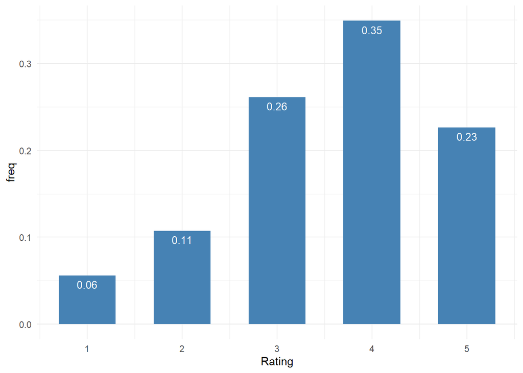

```r
tmp = data.frame(Rating = 1:5,
                 freq = as.vector(table(ratings$Rating)/nrow(ratings)))
ggplot(data = tmp, aes(x = Rating, y = freq)) +
  geom_bar(stat="identity", fill = 'steelblue', width = 0.6) +
  geom_text(aes(label=round(freq, dig=2)),
                vjust=1.6, color="white", size=3.5) +
  theme_minimal()
```

**Ratings per User**

Most users have left less than 500 ratings; about 9 users have had over 1300 ratings; one has 2314 ratings.

```r
tmp = ratings %>%
  group_by(UserID) %>%
  summarize(ratings_per_user = n())
summary(tmp$ratings_per_user)
```

```
##    Min. 1st Qu.  Median    Mean 3rd Qu.    Max.
##    20.0    44.0    96.0   165.6   208.0  2314.0
```

```r
stem(tmp$ratings_per_user)
```

```
##
##   The decimal point is 2 digit(s) to the right of the |
##
##    0 | 22222222222222222222222222222222222222222222222222222222222222222222+2922
##    1 | 00000000000000000000000000000000000000000000000000000000000000000000+1323
##    2 | 00000000000000000000000000000000000000000000000000000000000000000000+560
##    3 | 00000000000000000000000000000000000000000000000000000000000000011111+293
##    4 | 00000000000000000000000000000000000000000111111111111111111111111111+138
##    5 | 00000000000000011111111111111111111111112222222222222233333333333333+61
##    6 | 00000001111111111112222222222333333333333334444444555556666777777777+2
##    7 | 000000001111112222222333333333334444444555566666677777788888999999
##    8 | 0000112222222333333444444455555566667777777888899999
##    9 | 001122233444566667789
##   10 | 00011122224558
##   11 | 245678
##   12 | 1222234466789
##   13 | 024
##   14 |
##   15 | 22
##   16 | 0
##   17 | 4
##   18 | 5
##   19 |
##   20 |
##   21 |
##   22 |
##   23 | 1
```

```r
sum(tmp$ratings_per_user > 500)
```

```
## [1] 396
```

```r
sort(tmp$ratings_per_user[tmp$ratings_per_user>1300])
```

```
## [1] 1302 1323 1344 1518 1521 1595 1743 1850 2314
```

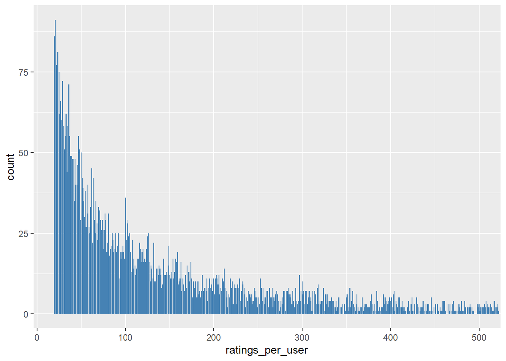

```r
tmp %>%
  ggplot(aes(ratings_per_user)) +
  geom_bar(fill = "steelblue") + coord_cartesian(c(20, 500))
```

Combining users and tmp, you could further explore how ratings_per_user depends on Gender, Age, and Occupation of users.

```r
tmp = tmp %>% full_join(users, by = 'UserID')
```

**Ratings per Movie** There are 31 movies that have received more than 2000 ratings. The most popular movie is “American Beauty (1999)”, followed by the “Star Wars” series. Throughout, popular means receiving many ratings; a popular movie may not be a highly-rated movie.

```r
tmp = ratings %>%
  group_by(MovieID) %>%
  summarize(ratings_per_movie = n(), ave_ratings = mean(Rating)) %>%
  inner_join(movies, by = 'MovieID')
summary(tmp$ratings_per_movie)
```

```
##    Min. 1st Qu.  Median    Mean 3rd Qu.    Max.
##     1.0    33.0   123.5   269.9   350.0  3428.0
```

```r
tmp %>%
  filter(ratings_per_movie > 2000) %>%
  arrange(desc = ratings_per_movie) %>%
  select(c("Title", "ratings_per_movie")) %>%
  print(n = 31)
```

```
## # A tibble: 31 × 2
##    Title                                                 ratings_per_movie
##    <chr>                                                             <int>
##  1 Alien (1979)                                                       2024
##  2 Toy Story (1995)                                                   2077
##  3 Terminator, The (1984)                                             2098
##  4 Pulp Fiction (1994)                                                2171
##  5 Ghostbusters (1984)                                                2181
##  6 Forrest Gump (1994)                                                2194
##  7 Godfather, The (1972)                                              2223
##  8 Shawshank Redemption, The (1994)                                   2227
##  9 Being John Malkovich (1999)                                        2241
## 10 Star Wars: Episode I - The Phantom Menace (1999)                   2250
## 11 E.T. the Extra-Terrestrial (1982)                                  2269
## 12 Groundhog Day (1993)                                               2278
```

[output cut: 19 more lines]

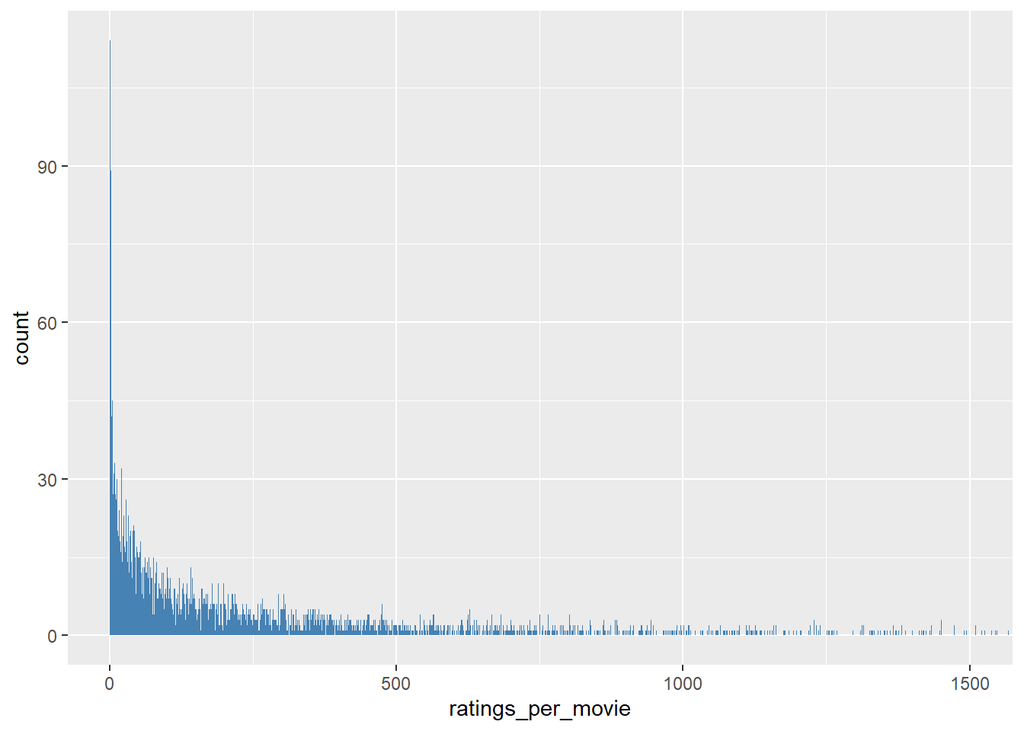

```r
tmp %>% ggplot(aes(ratings_per_movie)) +
  geom_bar(fill = "steelblue", width = 1) + coord_cartesian(c(1,1500))
```

```r
small_image_url = "https://liangfgithub.github.io/MovieImages/"
ratings %>%
  group_by(MovieID) %>%
  summarize(ratings_per_movie = n(),
            ave_ratings = round(mean(Rating), dig=3)) %>%
  inner_join(movies, by = 'MovieID') %>%
  filter(ratings_per_movie > 1000) %>%
  top_n(10, ave_ratings) %>%
  mutate(Image = paste0('<img src="',
                        small_image_url,
                        MovieID,
                        '.jpg?raw=true"></img>')) %>%
  select('Image', 'Title', 'ave_ratings') %>%
  arrange(desc(-ave_ratings)) %>%
  datatable(class = "nowrap hover row-border",
            escape = FALSE,
            options = list(dom = 't',
                          scrollX = TRUE, autoWidth = TRUE))
```

|  | Image | Title | ave_ratings |
| --- | --- | --- | --- |
| 1 |  | Sixth Sense, The (1999) | 4.406 |
| 2 |  | Casablanca (1942) | 4.413 |
| 3 |  | Dr. Strangelove or: How I Learned to Stop Worrying and Love the Bomb (1963) | 4.45 |
| 4 |  | Star Wars: Episode IV - A New Hope (1977) | 4.454 |
| 5 |  | Rear Window (1954) | 4.476 |
| 6 |  | Raiders of the Lost Ark (1981) | 4.478 |
| 7 |  | Schindler's List (1993) | 4.51 |
| 8 |  | Usual Suspects, The (1995) | 4.517 |
| 9 |  | Godfather, The (1972) | 4.525 |
| 10 |  | Shawshank Redemption, The (1994) | 4.555 |

**Distribution of Genres** First create a binary indicator for the 18 genres for each movie.

```r
genres = as.data.frame(movies$Genres, stringsAsFactors=FALSE)
tmp = as.data.frame(tstrsplit(genres[,1], '[|]',
                              type.convert=TRUE),
                    stringsAsFactors=FALSE)
genre_list = c("Action", "Adventure", "Animation",
               "Children's", "Comedy", "Crime",
               "Documentary", "Drama", "Fantasy",
               "Film-Noir", "Horror", "Musical",
               "Mystery", "Romance", "Sci-Fi",
               "Thriller", "War", "Western")
m = length(genre_list)
genre_matrix = matrix(0, nrow(movies), length(genre_list))
for(i in 1:nrow(tmp)){
  genre_matrix[i,genre_list %in% tmp[i,]]=1
}
colnames(genre_matrix) = genre_list
remove("tmp", "genres")
```

Then we can output historograms of the 18 genres baesd on movies or based on ratings.

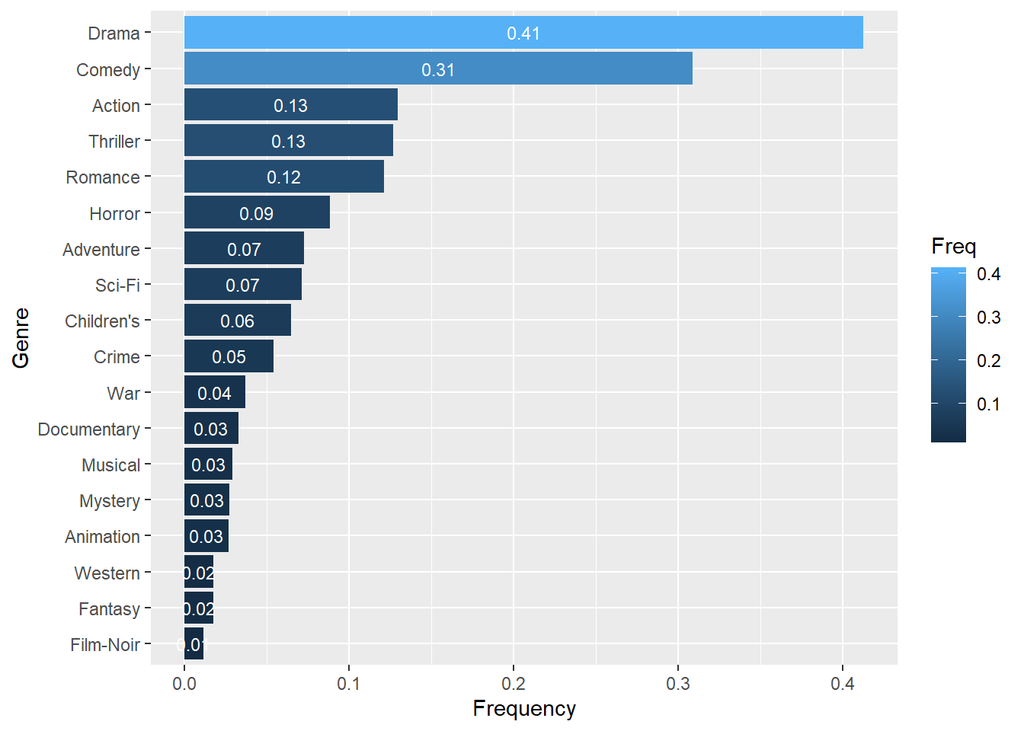

```r
data.frame(Genres = genre_list,
                 Freq = as.vector(colMeans(genre_matrix))) %>%
  ggplot(aes(reorder(Genres, Freq), Freq, fill = Freq)) +
  geom_bar(stat = "identity") +
    geom_text(aes(label = round(Freq, dig=2)),
            position = position_stack(vjust = 0.5),
            color="white", size=3) +
  coord_flip() +
  scale_colour_brewer(palette="Set1") +
  labs(y = 'Frequency', x = 'Genre')
```

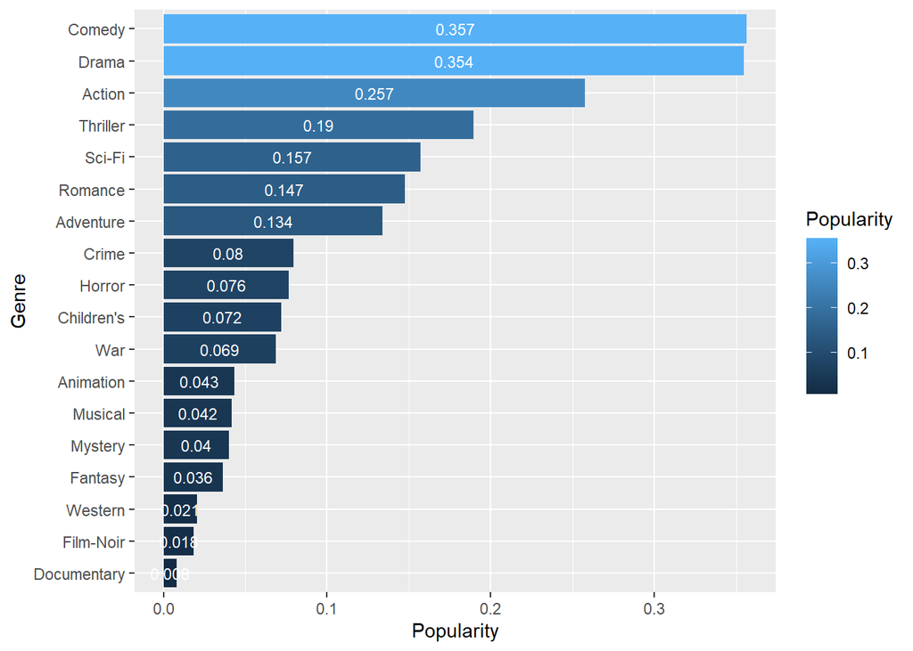

```r
tmp = ratings %>%
  left_join(data.frame(MovieID = movies$MovieID, genre_matrix),
            by = "MovieID") %>%
  select(-c("UserID", "MovieID", "Rating", "Timestamp"))
data.frame(Genres = genre_list,
                 Popularity = as.vector(colMeans(tmp))) %>%
  ggplot(aes(reorder(Genres, Popularity), Popularity, fill = Popularity)) +
  geom_bar(stat = "identity") +
  geom_text(aes(label = round(Popularity, dig=3)),
            position = position_stack(vjust = 0.5),
            color="white", size=3) +
  coord_flip() +
  labs(y = 'Popularity', x = 'Genre')
```

About half of the movies belong to only one genre; about one-third are categorized into two genres; a few are categorized into more than four genres. The movie “The Transformers” (1986) are categorized into six genres: Action, Animation, Children’s, Sci-Fi, Thriller, and War.

## System 1: Recommendation of Movie By Genre

System 1 gives the recommendation of movies by their genres. Users are given an option to select the genre of their choice and top 5 movies are recommended. Two different approaches were tried to give the recommendations. Approach 1 given below, displays the movie recommendations based on the popularity.

### Approach 1: Recommendation based on popularity

- MovieIDs with Ratings greater than 2 out of 5 are filtered and grouped based on their genres. That for a movie to be recommended, it should have atleast some rating (here 2/5) from each genre to be shortlisted.
- Top 5 Movies with higher individual ratings obtained from the above condition are recommended to the user.

```r
popular_genre = function(gfrominput)
{
  genre = ratings %>%
    group_by(MovieID) %>%
    summarize(ratings_per_movie = sum(Rating > 2)) %>%
    inner_join(movies, by = 'MovieID') %>%
    group_by(Genres) %>%
    arrange(desc = ratings_per_movie)
  genre = genre[grepl(gfrominput, genre$Genres, fixed = TRUE),]
  nr = nrow(genre)
  low = nr-5+1
  return(genre[nr:low,])
}
```

[figure not shown]

Recommendations of System 1: Approach 1

### Approach 2: Recommendation based on Movie Ratings

- Average rating for each movie is calculated and grouped by genre.
- Movies that have atleast 1000 ratings are then filtered and top 5 out of these filtered movies are presented to the user.

```r
popular_genre = function(gfrominput)
{
  genre = ratings %>%
    group_by(MovieID) %>%
    summarize(ratings_per_movie = n(), ave_ratings = mean(Rating)) %>%
    inner_join(movies, by = 'MovieID') %>%
    group_by(Genres) %>%
    filter(ratings_per_movie > 1000) %>%
    top_n(5, ave_ratings)
  genre = genre[grepl(gfrominput, genre$Genres, fixed = TRUE),]
  return(genre)
}
```

[figure not shown]

We can observe that different movies are recommended by two different approaches. We decided to go approach 1 for system 1, which is recommending movies by popularity.

## System 2: Collaborative Recommendation System

Two collaborative recommendation algorithms namely UBCF (User-Based Collaborative Filtering) and IBCF (Item-based Collaborative Filtering).

### Approach 1: User-Based Collaborative Filtering

- Based on the given input, we try to find the most similar users
- Cosine similarity is used to find the most similar users and select the one that takes least time.
- Based on similar users, we try to predict the movie ratings by taking the average of ratings given by these similar users. Weights are assigned to the predictions that have similarity

```r
library(recommenderlab)
myurl = "https://liangfgithub.github.io/MovieData/"
ratings = read.csv(paste0(myurl, 'ratings.dat?raw=true'),
                   sep = ':',
                   colClasses = c('integer', 'NULL'),
                   header = FALSE)
colnames(ratings) = c('UserID', 'MovieID', 'Rating', 'Timestamp')
i = paste0('u', ratings$UserID)
j = paste0('m', ratings$MovieID)
x = ratings$Rating
tmp = data.frame(i, j, x, stringsAsFactors = T)
Rmat = sparseMatrix(as.integer(tmp$i), as.integer(tmp$j), x = tmp$x)
rownames(Rmat) = levels(tmp$i)
colnames(Rmat) = levels(tmp$j)
Rmat = new('realRatingMatrix', data = Rmat)

train = Rmat[1:500, ]
test = Rmat[501, ]
```

A sparse matrix is created by **m x n** dimenions, **m** = the total no of users and **n** = the total no of movies. For instance, element at [1,1] represents the rating given by *user_1* for *movie_1*

```r
data = as(train, "matrix")
user.means = rowMeans(data, na.rm = TRUE)
data = data - user.means

newdata = as(test, "matrix")
newuser.mean = mean(newdata, na.rm = TRUE)
newdata = newdata - newuser.mean

sim = rep(0, dim(data)[1])
for(i in 1:length(sim))
{
tmp.y = as.vector(newdata)
ind.y = which(!is.na(tmp.y))
tmp.x = data[i, ]
ind.x = which(!is.na(tmp.x))
ind = intersect(ind.x, ind.y)
if (length(ind) > 0){
tmp.x = tmp.x[ind]
tmp.y = tmp.y[ind]
sim[i] = sum(tmp.x * tmp.y) / sqrt(sum(tmp.x^2) * sum(tmp.y^2))
}
}
sim = (1 + sim)/2

k = 20

idx = order(sim, decreasing = TRUE)[1:k]
sim[-idx]=0

mypred = colSums(data*sim, na.rm=TRUE)/colSums( (!is.na(data)) * sim )
mypred[!is.na(newdata)]= NA
mypred[is.nan(mypred)] = NA
mypred = mypred + newuser.mean
```

The above code represents the UBCF alogrithm without using Recommenderlab function.

```r
recommender.UBCF <- Recommender(train, method = "UBCF",
                                parameter = list(normalize = 'center',
                                                 method = 'Cosine',
                                                 nn = 20))

p.UBCF <- predict(recommender.UBCF, test, type="ratings")
p.UBCF <- as.numeric(as(p.UBCF, "matrix"))

sum(is.na(p.UBCF) != is.na(mypred)) ### should be zero
```

```
## [1] 0
```

```r
max(abs(p.UBCF - mypred), na.rm = TRUE)  ### should be less than 1e-06
```

```
## [1] 4.953572e-07
```

The predictions produced by the model we wrote are close enough to the predictions made by the Recommenderlab function. Thereby achieving the target benchmark set.

### Approach 2: Item-based Collaborative Filtering

This approach also has a similar steps as that of UBCF. But here, a correlation matrix is built between all the movies. Based on the user rating for a particular movie, a highly correlated movie is suggested fromt this large sparse matrix **m x m**, where **m** is the total no. of movies. This sparse matrix is built by using the cosine similarity.

```r
data = as(train, "matrix")
user.means = rowMeans(data, na.rm = TRUE)
data = data - user.means

newdata = as(test, "matrix")


sim1 = proxy::simil(data, method = "cosine", by_rows = F)
sim1 = (1 + sim1)/2

sim1 = as.matrix(sim1)

for(i in 1:ncol(data)){
  similar_items = tail(order(sim1[i,], decreasing = FALSE, na.last = FALSE), 30)
  sim1[i, -similar_items]= NA
}
```

```r
ra = as.vector(newdata)
ra_mat = matrix(rep(ra, each = 3706), nrow = 3706)
data12 = sim1 * ra_mat

non_na_vec = which(is.na(newdata))
mypred = rep(NA, times = ncol(newdata))

for (i in 1:length(non_na_vec)){
  num = sum(data12[non_na_vec[i],], na.rm =T)
  den = sum(!is.na(data12[non_na_vec[i],]))
  mypred[non_na_vec[i]] = num/den
}

mypred[is.infinite(mypred)] = NA
mypred[is.nan(mypred)] = NA
```

```r
recommender.IBCF <- Recommender(train, method = "IBCF",
                                parameter = list(normalize = 'center',
                                                 method = 'Cosine',
                                                 k = 30))

p.IBCF <- predict(recommender.IBCF, test, type="ratings")
p.IBCF <- as.numeric(as(p.IBCF, "matrix"))

## first output: should be less than 10
sum(is.na(p.IBCF) != is.na(mypred))
```

```
## [1] 1
```

```r
## second output: should be less than 10%
mydiff = abs(p.IBCF - mypred)
sum(mydiff[!is.na(mydiff)] > 1e-6) / sum(!is.na(mydiff))
```

```
## [1] 0.0880829
```

This approach has also passed the target benchmark set by the professor.

We deployed an IBCF recommendation system as part for System 2. This is because, the majority of the work is done during training (including sorting and computing the item-to-item M-by-M similarity matrix). Then it takes less time to display the top 10 movie recommendations. A snapshot of movie recommendations by system 2 can be seen below

[figure not shown]

## Link to Web Application

Movie Recommender System: https://konduru.shinyapps.io/project_4/

## References

- Book Recommender: Collaborative Filtering, Shiny. PHILIPP SPACHTHOLZ https://github.com/pspachtholz/BookRecommender
- Campuswire - Project 4: https://campuswire.com/c/G3D46BBBA/feed/19